# Model Performance And Fit - 2

One should look for what is and not what he thinks should be. (Albert Einstein)

# Module completion checklist

| Objective | Complete |
| --- | --- |
| Implement a custom neural network for different batch sizes |  |
| Evaluate the neural network for different number of epochs |  |

# Goal for this section

- We will again work with the `credit_card_data` dataset
- We will build a model and then compare the loss and accuracy of the validation data for different levels of epochs and batch sizes

# Wide and deep neural networks

- The architecture of a neural network is defined by 2 parameters: width and depth
  - Depth is measured by the number of layers in the neural network, excluding the input layer
  - Width is measured by the maximal number of nodes present in a layer of a neural network
- In general, as we increase the width and the depth in a model, the accuracy increases, but so does the complexity
- Choosing the depth and width of the layers in a neural network is a **trial-and-error process** highly dependent on the data we have in hand, but having a single hidden layer is always a good start
- Note: Remember that if we try to increase the width and depth of a neural network beyond a certain point, the model might overfit!

# Define and compile a sequential model

- Let’s create a convenience function to define and compile the model with an input layer, two hidden layers, and an output layer

```python
def create_model(lr = .0001):
  # Let's set the seed so that we can reproduce the results.
  tf.random.set_seed(1)
  opt = Adam(learning_rate = lr) # <- set optimizer

  model = Sequential([
          Dense(32, activation='relu', input_dim = 30),#<- set input and 1st hidden layer
          Dense(32, activation='relu'),              #<- set 2nd hidden layer
          Dense(1, activation='sigmoid')             #<- set output layer

  ])

  model.compile(optimizer = opt,            #<- set optimizer
                loss='binary_crossentropy', #<- set loss function to binary_crossentropy
                metrics=['accuracy'])       #<- set performance metric
  return model
```

# Fit the model

- We will now fit the model with **different batch sizes** and compare how the validation loss and the accuracy look by comparing their results
- We will keep the number of `epochs` the same for every experiment

# Default batch size

- The default batch size while we fit the model is `32`, and hence we need not specify the parameter explicitly

```python
model = create_model()
bt_default = model.fit(X_train_scaled, y_train,                  #<- train data and labels
                       epochs = 25,                              #<- number of epochs
                       validation_data = (X_val_scaled, y_val))  #<- pass val data
```

```bash
Epoch 1/25
657/657 [==============================] - 1s 994us/step - loss: 0.4889 - accuracy: 0.7938 - val_loss: 0.4522 - val_accuracy: 0.8196
Epoch 2/25
657/657 [==============================] - 1s 840us/step - loss: 0.4496 - accuracy: 0.8161 - val_loss: 0.4504 - val_accuracy: 0.8162
...
Epoch 24/25
657/657 [==============================] - 1s 858us/step - loss: 0.4372 - accuracy: 0.8169 - val_loss: 0.4337 - val_accuracy: 0.8202
Epoch 25/25
657/657 [==============================] - 1s 810us/step - loss: 0.4294 - accuracy: 0.8236 - val_loss: 0.4355 - val_accuracy: 0.8216
```

# Small batch size

- Let’s set the batch size to `8`

```python
model = create_model()
bt_small = model.fit(X_train_scaled, y_train,                 #<- train data and labels
                      epochs = 25,                              #<- number of epochs
                      batch_size= 8,                           #<- set batch_size
                      validation_data = (X_val_scaled, y_val))  #<- pass val data
```

```bash
Epoch 1/25
2625/2625 [==============================] - 2s 789us/step - loss: 0.4854 - accuracy: 0.7975 - val_loss: 0.4472 - val_accuracy: 0.8213
Epoch 2/25
2625/2625 [==============================] - 2s 732us/step - loss: 0.4517 - accuracy: 0.8153 - val_loss: 0.4482 - val_accuracy: 0.8171
...
Epoch 24/25
2625/2625 [==============================] - 2s 702us/step - loss: 0.4394 - accuracy: 0.8166 - val_loss: 0.4344 - val_accuracy: 0.8236
Epoch 25/25
2625/2625 [==============================] - 2s 702us/step - loss: 0.4318 - accuracy: 0.8223 - val_loss: 0.4348 - val_accuracy: 0.8216
```

# Large batch size

- Now, let’s set the batch size as `512`

```python
model = create_model()
bt_large = model.fit(X_train_scaled, y_train,   #<- train data + labels
                      epochs = 25,              #<- number of epochs
                      batch_size= 512,          #<- set batch_size
                      validation_data = (X_val_scaled, y_val))  #<- val data + labels
```

```bash
Epoch 1/25
42/42 [==============================] - 0s 4ms/step - loss: 0.5435 - accuracy: 0.7636 - val_loss: 0.4715 - val_accuracy: 0.8071
Epoch 2/25
42/42 [==============================] - 0s 2ms/step - loss: 0.4683 - accuracy: 0.8081 - val_loss: 0.4567 - val_accuracy: 0.8158
...
Epoch 24/25
42/42 [==============================] - 0s 2ms/step - loss: 0.4367 - accuracy: 0.8205 - val_loss: 0.4324 - val_accuracy: 0.8249
Epoch 25/25
42/42 [==============================] - 0s 2ms/step - loss: 0.4284 - accuracy: 0.8240 - val_loss: 0.4298 - val_accuracy: 0.8249
```

# Visualize results for various batch sizes

- Let’s create a dataframe with the loss and accuracy for training and validation data along with their epoch and batch size

```python
batch_sizes = []

for exp, result in zip([bt_default, bt_small, bt_large], ["32", "8", "512"]):

  df = pd.DataFrame.from_dict(exp.history)
  df['epoch'] = df.index.values
  df['Batch Size'] = result

  batch_sizes.append(df)

df_summary = pd.concat(batch_sizes)
df_summary['Batch Size'] = df_summary['Batch Size'].astype('str')
```

# Visualize results for various batch sizes (cont’d)

[figure not shown]

```python
sns.lineplot(x='epoch', y='val_accuracy',
             hue='Batch Size', data=df_summary)
```

# Visualize results for various batch sizes (cont’d)

[figure not shown]

```python
sns.lineplot(x='epoch', y='val_loss',
             hue='Batch Size', data=df_summary)
```

# Module completion checklist

| Objective | Complete |
| --- | --- |
| Implement a custom neural network for different batch sizes | **✔** |
| Evaluate the neural network for different number of epochs |  |

# Using a different number of epochs

- Now, we will train the model using different number of `epochs` and compare our results
- We will keep the batch size and the learning rate at their default values in this analysis

# Higher number of epochs

- We initially run the model by setting the number of epochs as `150` with the default `batch_size`

```python
ep_high = create_model().fit(X_train_scaled, y_train,
                             epochs = 150,
                             validation_data=(X_val_scaled, y_val))
```

```bash
Epoch 1/150
657/657 [==============================] - 1s 1ms/step - loss: 0.4889 - accuracy: 0.7938 - val_loss: 0.4522 - val_accuracy: 0.8196
Epoch 2/150
657/657 [==============================] - 1s 919us/step - loss: 0.4496 - accuracy: 0.8161 - val_loss: 0.4504 - val_accuracy: 0.8162
...
Epoch 149/150
657/657 [==============================] - 1s 788us/step - loss: 0.4204 - accuracy: 0.8253 - val_loss: 0.4492 - val_accuracy: 0.8222
Epoch 150/150
657/657 [==============================] - 1s 800us/step - loss: 0.4210 - accuracy: 0.8242 - val_loss: 0.4761 - val_accuracy: 0.8227
```

# Medium number of epochs

- Let’s set the epochs parameter to `100` and fit the model

```python
ep_medium = create_model().fit(X_train_scaled, y_train,
                               epochs = 100,
                               validation_data=(X_val_scaled, y_val))
```

```bash
Epoch 1/100
657/657 [==============================] - 1s 990us/step - loss: 0.4889 - accuracy: 0.7938 - val_loss: 0.4522 - val_accuracy: 0.8196
Epoch 2/100
657/657 [==============================] - 1s 841us/step - loss: 0.4496 - accuracy: 0.8161 - val_loss: 0.4504 - val_accuracy: 0.8162
...
Epoch 99/100
657/657 [==============================] - 1s 802us/step - loss: 0.4281 - accuracy: 0.8200 - val_loss: 0.4500 - val_accuracy: 0.8209
Epoch 100/100
657/657 [==============================] - 1s 799us/step - loss: 0.4286 - accuracy: 0.8217 - val_loss: 0.4537 - val_accuracy: 0.8220
```

# Lower number of epochs

- We set the number of epochs as `25` and fit the model

```python
ep_low = create_model().fit(X_train_scaled, y_train,
                            epochs = 25,
                            validation_data = (X_val_scaled, y_val))
```

```bash
Epoch 1/25
657/657 [==============================] - 1s 1ms/step - loss: 0.4889 - accuracy: 0.7938 - val_loss: 0.4522 - val_accuracy: 0.8196
Epoch 2/25
657/657 [==============================] - 1s 884us/step - loss: 0.4496 - accuracy: 0.8161 - val_loss: 0.4504 - val_accuracy: 0.8162
...
Epoch 24/25
657/657 [==============================] - 1s 917us/step - loss: 0.4372 - accuracy: 0.8169 - val_loss: 0.4337 - val_accuracy: 0.8202
Epoch 25/25
657/657 [==============================] - 1s 878us/step - loss: 0.4294 - accuracy: 0.8236 - val_loss: 0.4355 - val_accuracy: 0.8216
```

# Visualize results for epoch sizes

- Let’s create a dataframe with the loss and accuracy for training and validation data along with their corresponding epoch and the number of epochs they have been trained on

```python
epoch_sizes = []

for exp, result in zip([ep_high, ep_medium, ep_low], ["150", "100", "25"]):

  df = pd.DataFrame.from_dict(exp.history)
  df['epoch'] = df.index.values
  df['Number of epochs'] = result

  epoch_sizes.append(df)

df_epochs = pd.concat(epoch_sizes)
df_epochs['Number of epochs'] = df_epochs['Number of epochs'].astype('str')
```

# Visualize results for epoch sizes (cont’d)

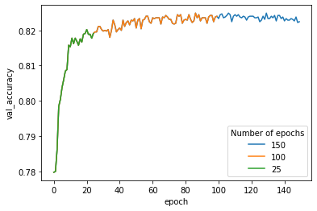

```python
sns.lineplot(x='epoch', y='val_accuracy', hue='Number of epochs', data=df_epochs)
```

# Visualize results for epoch sizes (cont’d)

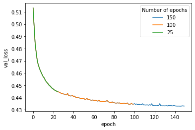

```python
sns.lineplot(x='epoch', y='val_loss', hue='Number of epochs', data=df_epochs)
```

# Knowledge check

# Exercise

You are now ready to try tasks 8-12 in the Exercise for this topic

# Module completion checklist

| Objective | Complete |
| --- | --- |
| Implement a custom neural network for different batch sizes | **✔** |
| Evaluate the neural network for different number of epochs | **✔** |

# Congratulations on completing this module!